# Netflix TV Shows and Movies Data Frame Analysis

What is the average duration of tv shows on netflix by year?

```python
netflix_tvshows = netflix[netflix['type'] == 'SHOW']
average_tv = netflix_tvshows.groupby(['release_year'])['runtime'].mean()
average_tv
```

```
release_year
1969    30.000000
1972    43.000000
1981    15.000000
1982    51.000000
1983    26.000000
1984    10.000000
1987    10.000000
1988    50.000000
1989    23.666667
1992    28.000000
1993    28.000000
1994    31.666667
1995    23.000000
1996    21.000000
```

[output cut: 27 more lines]

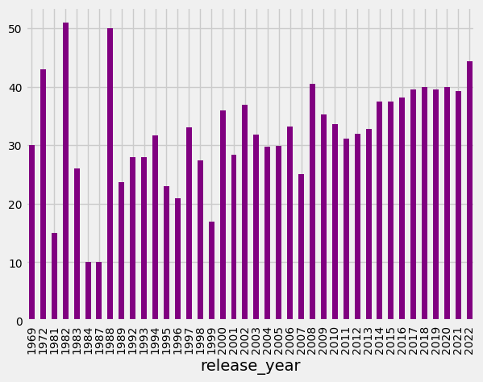

```python
import matplotlib as plt
average_tv.plot.bar(fontsize=10, x = 'release_year', y = 'runtime', color = ['purple'])
```

**Query #8** How many movies and tv shows have an imdb score above 7.0?

```python
netflix_good = netflix[netflix['imdb_score'] > 7.0]['index'].count()
netflix_good
```

```
1888
```

**Insighs:** About a third of the movies and tv shows on Netflix have an imdb rating above 7.0 out of 10.0, which is a generally good score for imdb.

**Query #9**

```python
netflix_the = netflix.groupby(netflix['title'].str.contains(' the ' or 'The '))['index'].count()
netflix_the[True]
```

```
407
```

**Insights:** We thought that more of the movies and tv shows in Netflix would have the word 'the' in the title, as we assumed it was the most used word in the English language.

**Query #10**

Which movies or tv shows have the least number of imdb votes?

```python
netflix_no_na = netflix[netflix['imdb_votes'] != "NA"]
lowest_imdb_votes = netflix_no_na.sort_values(['imdb_votes'], ascending=True).head(10)
lowest_imdb_votes
```

|  | index | id | title | type | description | release_year | age_certification | runtime | imdb_id | imdb_score | imdb_votes |
| --- | --- | --- | --- | --- | --- | --- | --- | --- | --- | --- | --- |
| 4110 | 4110 | tm835414 | Sitara | MOVIE | A Bangaldeshi housewife crosses the border to start her a new life where she struggles to deal with the pain and betrayal of her own family and making a living on her own. | 2019 | NA | 128 | tt7654668 | 8.0 | 5.0 |
| 5186 | 5186 | ts288861 | Let's Eat | SHOW | A food-blogging insurance agent encounters a friend from elementary school with a vendetta against him -- but soon becomes her sidekick. | 2021 | TV-14 | 60 | tt15978704 | 8.2 | 5.0 |
| 2752 | 2752 | tm407349 | The Birth Reborn 2 | MOVIE | NA | 2018 | PG | 91 | tt16114198 | 6.6 | 5.0 |
| 822 | 822 | tm166740 | Chhota Bheem & Krishna in Mayanagari | MOVIE | Bheem and his Friends are having a great time in Dwarka with their friend Kanha.Mayandri tries to attack Kanha with some leopards but fails as Kanha fights them off with ease.Bheem gets injured and hi… | 2011 | G | 66 | tt16235600 | 9.0 | 5.0 |
| 2077 | 2077 | ts82268 | GHOUL | SHOW | A newly minted military interrogator arrives at a covert detention center to discover that some of the terrorists held there are not of this world. | 2018 | TV-MA | 46 | tt5909930 | 8.0 | 6.0 |
| 4175 | 4175 | ts298837 | Badanamu Stories | SHOW | Badanamu Stories explore themes central to the lives of preschool children but in ways that inject whimsy, imagination, and wonder into the everyday. | 2020 | TV-Y | 13 | tt14857600 | 3.4 | 6.0 |
| 4180 | 4180 | ts90466 | Hong Kong West Side Stories | SHOW | The intimate lives of young men and women from Hong Kong are linked by loosely connected stories about love, lust, separation and deceit. | 2019 | TV-MA | 23 | tt10284430 | 5.7 | 6.0 |
| 91 | 91 | ts63001 | High Risk | SHOW | High Risk is a program aired by the CBS television network as part of its 1988 fall lineup.\n\nThe genesis of High Risk was a 1988 strike by members of both the Writers Guild of America, East and Writ… | 1988 | TV-PG | 50 | tt0094478 | 3.8 | 6.0 |
| 1168 | 1168 | tm206698 | Ouija: Origin of Evil | MOVIE | In 1965 Los Angeles, a widowed mother and her two daughters add a new stunt to bolster their sÃ©ance scam business and unwittingly invite authentic evil into their home. When the youngest daughter is … | 2016 | PG-13 | 99 | tt4361050 | 5.3 | 6.0 |
| 4398 | 4398 | tm843408 | She Is | MOVIE | Can one woman have everything? Facing her 40s, a highly accomplished woman, with a host of suitors at her feet, faces hard decisions about love, family, and her future. | 2019 | NA | 106 | tt14605914 | 5.8 | 6.0 |

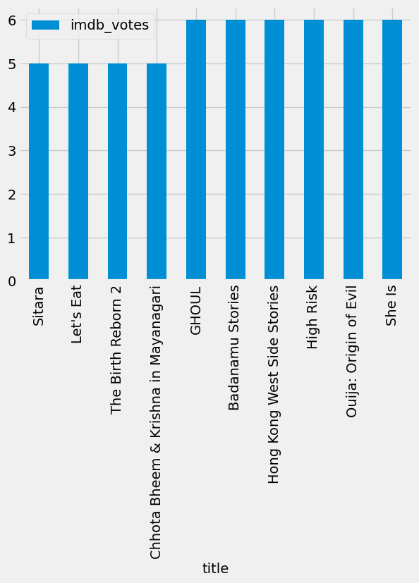

```python
import matplotlib as plt
lowest_imdb_votes.plot.bar(x = 'title', y = 'imdb_votes')
```

**Insights:** There is no correlation between imdb votes and the imdb score. However, the small amount of votes mean that each vote holds a greater share of determining the overall imdb score. So, one bad review could drastically decrease the imdb score.